# Recommendation System

## Doc2vec + Wide & Deep 을 이용한 추천시스템

### J. H. Park | 2017.08.16.

### 순서

1. 데이터 소개
2. Doc2Vec
3. Wide & Deep
4. Recommendation
5. Cold start 문제
6. 결론

본 문서에 사용된 데이터는 Lpoint 2016년 공모전에서 제공받은 데이터임을 밝힙니다.

## Memory based vs. Model based

Memory based 추천 시스템은 일반적으로 협험 필터링(Collaborative filterting; CF)라고도 합니다. Model based 추천 시스템은 Matrix factorization이나 Neural Network를 이용한 추천시스템을 말합니다.

Memory based CF는 사용자의 선호도(Rating) 기반으로 User 또는 Item의 유사도를 계산하여 추천을 해주는 방식입니다. 이 방식의 단점은 다음과 같습니다.

- Rating에 의존적(표본에 의존적)
- 그러므로 확장성(Scalability)가 떨어짐

이번 분석에서 사용한 Model based 방식을 설명하자면, 데이터를 기반으로 Training을 하여 패턴을 발견하는 기법입니다. 이 Model based 추천시스템은 Meomory based 방식의 단점을 보완하는 장점이 있지만 그만큼 Cost가 많이 든다는 단점이 있습니다.

### Neurla Network for Recommender system

각 User의 상품 구매 상황을 바이너리로 표현을 합니다. 만약 RBM을 사용하는 추천시스템이라면 Input과 Output에 똑같은 데이터가 들어가겠지만, 이번 분석에서는 바이너리 데이터가 Input에 들어가기 전에 Word2Vec 기술을 이용해서 900개 정도의 아이템을 300 차원으로 줄입니다.  
이 과정에서 아이템들이 벡터화 되고 유사도를 측정할 수 있기때문에, 벡터 연산을 통해 추론을 내릴 수 있다는 장점이 있습니다. 이렇게 되면, 비슷한 아이템들은 한데 묶이기 때문에 Rating에 덜 민감해지고, 확장성이 증가될 것입니다.

이렇게 Embedding된 Item matrix와 User-Feature등을 합하여 Input으로 넣고, 각 User의 상품 구매 현황을 바이너리로 표현한 Traget variable로 Training합니다.

# 1. 데이터 소개

데이터의 row는 고객의 전체 거래상품들이 아니라 한 영수증(한 번 결제)상에 거래된 상품목록입니다. (이하 Session 이라고 표현)

해당 데이터가 꽤 크므로 간단한 분석용으로 줄였습니다.

- B 제휴사 거래내역
- 한 Session상 2개 품목 이상인 거래
- 10번 이상 거래내역이 있는 고객

위 조건 중에서 고객별로 시간상 최근 거래내역 10개를 가지고 왔습니다.  
'각 데이터는 아래 진행될 분석 흐름에 맞게 사전에 `R`로 핸들링 하였습니다.

```python
import pandas as pd
import numpy as np
import matplotlib.pyplot as plt
import copy as cp
```

Train

```python
train_data = pd.read_csv("./Lpoint_C/data/train_data.csv", encoding="cp949")
train_label = pd.read_csv("./Lpoint_C/data/train_label.csv", encoding="cp949")
train_user_feartures = pd.read_csv("./Lpoint_C/data/train_categorical.csv", encoding="cp949")
train_Segment = pd.read_csv("./Lpoint_C/data/train_Segment.csv", encoding="cp949")
```

Test

```python
test_data = pd.read_csv("./Lpoint_C/data/test_data.csv", encoding="cp949")
test_label = pd.read_csv("./Lpoint_C/data/test_label.csv", encoding="cp949")
test_user_feartures = pd.read_csv("./Lpoint_C/data/test_categorical.csv", encoding="cp949")
test_Segment = pd.read_csv("./Lpoint_C/data/test_Segment.csv", encoding="cp949")

test_label_eval = pd.read_csv("./Lpoint_C/data/test_label_real.csv", encoding="cp949")
```

```python
train_label = train_label.fillna(0)
train_Segment = train_Segment.fillna(0)
test_label_eval = test_label_eval.fillna(0)
test_Segment = test_Segment.fillna(0)

print("결측치 0으로 처리")
```

```
결측치 0으로 처리
```

### Doc2Vec에 Input 으로 사용될 형식

```python
train_data.head()
```

|  | item | 영수증번호 | 고객번호 |
| --- | --- | --- | --- |
| 0 | C030901/일반계란 C070103/가공우유 C110701/일반두유 C170206... | 2196 | 3074 |
| 1 | C060506/일반떡 C110305/과채음료세트 C120101/일반소주 C12050... | 2243 | 739 |
| 2 | C030109/깻잎 C030204/오이 C030301/감자 C050302/볶음탕용닭 | 2249 | 7922 |
| 3 | C070102/기능성우유 C150305/쿠키케이크 | 2250 | 7922 |
| 4 | C010110/딸기 C010119/사과선물세트 | 2262 | 18984 |

### Wide&Deep에 Label 로 사용될 형식

```python
train_label.head()
```

|  | C010101/사과 | C010102/배 | C010103/감 | C010104/귤류 | C010105/유자/모과 | C010106/복숭아 | C010107/자두 | C010108/살구 | C010109/매실 | C010110/딸기 | ... | C170651/자연/과학완구 | C170653/미술/창작완구 | C170654/스포츠완구 | C170655/실외놀이완구 | C170656/물놀이용품 | C170657/미니자동차 | C170658/피규어 | C170660/콜렉션인형 | C170662/역할놀이 | C170701/생활잡화균일가 |
| --- | --- | --- | --- | --- | --- | --- | --- | --- | --- | --- | --- | --- | --- | --- | --- | --- | --- | --- | --- | --- | --- |
| 0 | 0.0 | 0.0 | 0.0 | 0.0 | 0.0 | 0.0 | 0.0 | 0.0 | 0.0 | 0.0 | ... | 0.0 | 0.0 | 0.0 | 0.0 | 0.0 | 0.0 | 0.0 | 0.0 | 0.0 | 0.0 |
| 1 | 0.0 | 0.0 | 0.0 | 0.0 | 0.0 | 0.0 | 0.0 | 0.0 | 0.0 | 0.0 | ... | 0.0 | 0.0 | 0.0 | 0.0 | 0.0 | 0.0 | 0.0 | 0.0 | 0.0 | 1.0 |
| 2 | 0.0 | 0.0 | 0.0 | 0.0 | 0.0 | 0.0 | 0.0 | 0.0 | 0.0 | 0.0 | ... | 0.0 | 0.0 | 0.0 | 0.0 | 0.0 | 0.0 | 0.0 | 0.0 | 0.0 | 0.0 |
| 3 | 0.0 | 0.0 | 0.0 | 0.0 | 0.0 | 0.0 | 0.0 | 0.0 | 0.0 | 0.0 | ... | 0.0 | 0.0 | 0.0 | 0.0 | 0.0 | 0.0 | 0.0 | 0.0 | 0.0 | 0.0 |
| 4 | 0.0 | 0.0 | 0.0 | 0.0 | 0.0 | 0.0 | 0.0 | 0.0 | 0.0 | 1.0 | ... | 0.0 | 0.0 | 0.0 | 0.0 | 0.0 | 0.0 | 0.0 | 0.0 | 0.0 | 0.0 |

5 rows × 884 columns

### Wide&Deep에 User Features 로 사용될 형식

```python
train_user_feartures.head()
```

|  | 성별 | 연령대 | A거주지역 |
| --- | --- | --- | --- |
| 0 | F | 50세~54세 | A24 |
| 1 | F | 60세이상 | A100 |
| 2 | F | 35세~39세 | A210 |
| 3 | F | 35세~39세 | A210 |
| 4 | F | 50세~54세 | A100 |

본 실험에서는 고객별로 가장 최근 구매 내역을 Test 로 선정하고, 최근 9번 까지의 구매내역을 Train 데이터로 선정하였습니다.  
(Test 데이터는 추천 방식에 따라 달라질 수 있습니다. )

- Train : 94,785 건
- Test : 13,915 건

한 Session에서 결제하는 상품의 개수는 다음과 같습니다.

```python
Train_session = train_label.apply(np.sum, axis=1)
Test_session = test_label_eval.apply(np.sum, axis=1)
```

```python
from matplotlib import font_manager, rc
font_fname = '/usr/share/fonts/truetype/nanum/NanumBarunGothic.ttf'
font_name = font_manager.FontProperties(fname=font_fname).get_name()
rc('font', family=font_name)
```

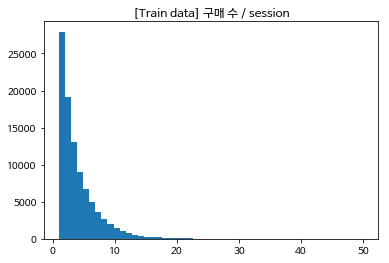

```python
plt.hist(Train_session, 50)
plt.title(u'[Train data] 구매 수 / session')
plt.show()
```

```python
Train_session.agg(['min','max','mean'])
```

```
min      1.000000
max     50.000000
mean     3.613979
dtype: float64
```

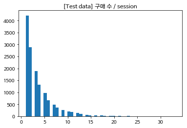

```python
plt.hist(Test_session, 50)
plt.title(u'[Test data] 구매 수 / session')
plt.show()
```

```python
Test_session.agg(['min','max','mean'])
```

```
min      1.000000
max     33.000000
mean     3.588861
dtype: float64
```

한 번 결제할 때 구매되는 상품의 개수는 평균적으로 3.5개입니다.

Train data 에서 가장 많이 구매된 상품은 다음과 같습니다.

```python
train_label_Rating = train_label.apply(np.sum, axis = 0)
train_label_Rating = pd.DataFrame(train_label_Rating)
train_label_Rating.nlargest(15, 0)
```

|  | 0 |
| --- | --- |
| C170206/종량제봉투 | 12763.0 |
| C070101/일반우유 | 8321.0 |
| C170701/생활잡화균일가 | 8096.0 |
| C030401/두부류 | 7609.0 |
| C150405/일반스낵 | 7322.0 |
| C030901/일반계란 | 6281.0 |
| C010206/바나나 | 5364.0 |
| C120201/국산맥주 | 4959.0 |
| C110101/생수 | 4948.0 |
| C150101/국물봉지라면 | 4885.0 |
| C150401/감자스낵 | 4541.0 |
| C070202/마시는요구르트 | 4444.0 |
| C120601/공병/공박스 | 4063.0 |
| C070103/가공우유 | 3952.0 |
| C120101/일반소주 | 3650.0 |

# 2. Doc2Vec

```python
len(train_label.columns)
```

```
884
```

구매내역 데이터를 one-hot 인코딩으로 바꾸게 되면 column은 884개의 label을 가지고 있습니다. 884개의 상품이 거래됐다는 뜻입니다. 이 데이터를 input으로 그냥 넣기에는 고전적 deep learning 방식이며 one-hot 방식을 취하므로 "사과" 라는 데이터를 구매한 특징을 잘 살리지 못할 수 있습니다.

이러한 이유로 해당 데이터를 Gensim의 Doc2Vec기술[[2]](https://arxiv.org/abs/1405.4053) 로 Embedding을 제안해 볼 수 있습니다. Hinton 교수님이 설명한 Deep learning에서 분산표현의 의미를 살리자는 것입니다.  
NLP 계열에서 사용하는 Doc2Vec을 상품에 적용한 Item2Vec 이라고 말하고 싶습니다.

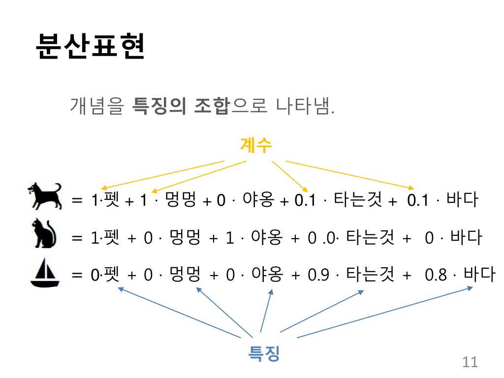

```python
from IPython.display import Image
Image('images/분산표현2.png')
```

```python
train_docs = [(str(row['item']).split(), row['고객번호']) for idx, row in train_data.iterrows()]
test_docs = [(str(row['item']).split(), row['고객번호']) for idx, row in test_data.iterrows()]
```

```python
train_docs[0]
```

```
(['C030901/일반계란', 'C070103/가공우유', 'C110701/일반두유', 'C170206/종량제봉투'], 3074)
```

위 list는 `ID:3074` 인 고객이 한 번 결제할 때 구매한 내역입니다.

```python
from gensim.models import doc2vec
from collections import namedtuple
import multiprocessing
```

```python
TaggedDocument = namedtuple('TaggedDocument', 'words tags')
tagged_train_docs = [TaggedDocument(d, [c]) for d, c in train_docs]
tagged_test_docs = [TaggedDocument(d, [c]) for d, c in test_docs]

cores = multiprocessing.cpu_count()
```

해당 Doc2Vec 모형의 Parameters는 [Rakuten [1]](https://www.slideshare.net/rakutentech/recommender-system-with-distributed-representation)의 "Doc2Vec을 이용한 상품추천 시스템"에서 가장 좋았던 Parameter 값들을 사용했습니다.

```python
if True:
    doc_vectorizer = doc2vec.Doc2Vec(

    dm = 0,            # PV-DBOW
    dbow_words = 0,    # w2v simultaneous with DBOW d2v / default 0
    window = 8,        # distance between the predicted word and context words
    size = 300,        # vector size
    alpha = 0.025,     # learning-rate
    min_alpha = 0.025, # min learning-rate

    seed = 1,

    sample= 1e-5,      # threshold for configuring
    min_count=3,       # ignore with freq lower
    workers=cores,     # multi cpu
    hs = 1             # hierarchical softmax / default 0
    )

    doc_vectorizer.build_vocab(tagged_train_docs)
    print(str(doc_vectorizer))

    for epoch in range(20):
        doc_vectorizer.train(tagged_train_docs)
        doc_vectorizer.alpha -= 0.001
        doc_vectorizer.min_alpha = doc_vectorizer.alpha

# To save
    doc_vectorizer.save('./Doc_model/Lpoint_Final_Final.model')
```

```
Doc2Vec(dbow,d300,n5,hs,mc3,s1e-05,t16)
```

```python
# To load
doc_vectorizer=doc2vec.Doc2Vec.load('./Doc_model/Lpoint_Final_Final.model')
```

```python
train_item = [doc_vectorizer.infer_vector(doc.words) for doc in tagged_train_docs]
train_item_pd = pd.DataFrame(train_item)
train_item_pd.head()
```

|  | 0 | 1 | 2 | 3 | 4 | 5 | 6 | 7 | 8 | 9 | ... | 290 | 291 | 292 | 293 | 294 | 295 | 296 | 297 | 298 | 299 |
| --- | --- | --- | --- | --- | --- | --- | --- | --- | --- | --- | --- | --- | --- | --- | --- | --- | --- | --- | --- | --- | --- |
| 0 | 0.000216 | 0.001162 | 0.001070 | -0.000053 | 0.000256 | -0.000708 | 0.001401 | -0.000950 | 0.000361 | -0.001105 | ... | 0.000288 | -0.000951 | 0.001310 | -0.001364 | 0.000703 | 0.000588 | -0.000839 | 0.000485 | -0.001070 | -0.000490 |
| 1 | 0.014992 | -0.069725 | -0.226130 | 0.245219 | -0.084408 | 0.052285 | 0.053115 | 0.042835 | 0.055734 | -0.068813 | ... | -0.089656 | 0.186806 | 0.043841 | -0.013601 | -0.174875 | 0.096060 | 0.122577 | 0.048859 | -0.114520 | -0.141565 |
| 2 | 0.007743 | -0.003382 | -0.005416 | 0.014197 | -0.003171 | -0.003004 | 0.002994 | 0.002291 | 0.005409 | -0.001246 | ... | -0.002302 | 0.006366 | 0.004461 | 0.004323 | -0.002202 | 0.006268 | -0.000805 | -0.001879 | 0.007050 | -0.006022 |
| 3 | -0.000174 | 0.000518 | -0.001118 | -0.002621 | 0.002093 | 0.002003 | -0.002465 | 0.003878 | 0.001486 | -0.000792 | ... | 0.000938 | 0.001940 | -0.001054 | 0.000257 | 0.000195 | -0.000163 | -0.002153 | -0.001063 | 0.001965 | -0.000064 |
| 4 | 0.023838 | -0.012118 | -0.022630 | -0.003656 | -0.016263 | 0.022470 | 0.003181 | 0.005158 | 0.020210 | 0.002528 | ... | -0.025466 | 0.016052 | -0.018334 | 0.020713 | -0.061371 | -0.014691 | 0.002276 | 0.016709 | -0.001772 | -0.006031 |

5 rows × 300 columns

```python
test_item = [doc_vectorizer.infer_vector(doc.words) for doc in tagged_test_docs]
test_item_pd = pd.DataFrame(test_item)
```

# 3. Wide & Deep learning

Google 의 Wide&Deep Model[[3]](https://arxiv.org/abs/1606.07792) 은 추천시스템을 위해 태어났다고 해도 생각해도 좋습니다. 간단한 예를 들어보겠습니다.

- 날개가 달린 동물은 날 수 있다.

Deep Learning을 이용해서 위 `"Feature"`를 학습할 수 있습니다. 이것을 일반화(generalization) 라고 말합니다.. 하지만, 이는 모든 상황에 적용되지 않기 때문에 문제가 있습니다.

- 팽귄은 날개가 있다. 하지만 날지 못한다.

모형은 이렇게 특별한 경우를 기억해야 합니다. 이것은 Wide Linear 모형으로 문제를 해결할 수 있고, 기억(memorization) 이라고 말합니다.

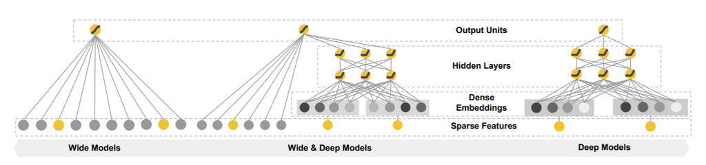

```python
Image('images/wide_n_deep.png')
```

### Define Base Feature Columns

```python
import tensorflow as tf
from tensorflow.contrib import layers
from datetime import datetime
from sklearn.preprocessing import LabelEncoder
le = LabelEncoder()
```

Wide & Deep 모형은 다른 모형과 다른점이 있습니다. 바로 입력 데이터가 2개라는 것입니다. Wide Linear 에는 입력 데이터들의 교호작용을 적용해서 넣고, Deep learning 에는 일반적인 입력 데이터를 넣습니다. 그래서 두 모형에 들어갈 입력 데이터를 각각 정의해야 합니다.

순서

1. Wide input을 만든다.
   - 여기에는 user features 가 들어가지 않는다.
   - 구매내역 데이터와 대분류코드 데이터의 cross column을 추가한다.
2. Deep input을 만든다.

### 3.1. Wide input

```python
cross_col =[]
for i in range(16):
    for j in range(16-i):
        cross_col.append([train_Segment.columns[i], train_Segment.columns[i + j + 1]])
```

```python
len(cross_col)
```

```
136
```

```python
train_item_pd_ = cp.deepcopy(train_item_pd)
test_item_pd_ = cp.deepcopy(test_item_pd)
train_Segment_ = cp.deepcopy(train_Segment)
test_Segment_ = cp.deepcopy(test_Segment)

train_Segment_str = train_Segment_.astype(str)
test_Segment_str = test_Segment_.astype(str)
```

```python
train_wide_ = pd.concat([train_item_pd_, train_Segment_str], axis=1)
test_wide_ = pd.concat([test_item_pd_, test_Segment_str], axis=1)
```

### Cross columns

```python
def cross_columns(data, cross_colnames):
    for i in cross_colnames:
        tmp = 0
        for j in i:
            tmp += 1
            if tmp == 1:
                cross_data = data[j]
                columns = j
            else:
                cross_data = cross_data + data[j]
                columns = columns + "+" + j
        data[columns] = cross_data

    return data
```

```python
%time wide_cross = cross_columns(train_wide_, cross_col)
%time wide_cross_test = cross_columns(test_wide_, cross_col)
wide_cross.head()
```

```
CPU times: user 1.18 s, sys: 128 ms, total: 1.3 s
Wall time: 1.3 s
CPU times: user 228 ms, sys: 20 ms, total: 248 ms
Wall time: 248 ms
```

|  | 0 | 1 | 2 | 3 | 4 | 5 | 6 | 7 | 8 | 9 | ... | X13+X14 | X13+X15 | X13+X16 | X13+X17 | X14+X15 | X14+X16 | X14+X17 | X15+X16 | X15+X17 | X16+X17 |
| --- | --- | --- | --- | --- | --- | --- | --- | --- | --- | --- | --- | --- | --- | --- | --- | --- | --- | --- | --- | --- | --- |
| 0 | 0.000216 | 0.001162 | 0.001070 | -0.000053 | 0.000256 | -0.000708 | 0.001401 | -0.000950 | 0.000361 | -0.001105 | ... | 0.00.0 | 0.00.0 | 0.00.0 | 0.01.0 | 0.00.0 | 0.00.0 | 0.01.0 | 0.00.0 | 0.01.0 | 0.01.0 |
| 1 | 0.014992 | -0.069725 | -0.226130 | 0.245219 | -0.084408 | 0.052285 | 0.053115 | 0.042835 | 0.055734 | -0.068813 | ... | 1.00.0 | 1.01.0 | 1.01.0 | 1.01.0 | 0.01.0 | 0.01.0 | 0.01.0 | 1.01.0 | 1.01.0 | 1.01.0 |
| 2 | 0.007743 | -0.003382 | -0.005416 | 0.014197 | -0.003171 | -0.003004 | 0.002994 | 0.002291 | 0.005409 | -0.001246 | ... | 0.00.0 | 0.00.0 | 0.00.0 | 0.00.0 | 0.00.0 | 0.00.0 | 0.00.0 | 0.00.0 | 0.00.0 | 0.00.0 |
| 3 | -0.000174 | 0.000518 | -0.001118 | -0.002621 | 0.002093 | 0.002003 | -0.002465 | 0.003878 | 0.001486 | -0.000792 | ... | 0.00.0 | 0.01.0 | 0.00.0 | 0.00.0 | 0.01.0 | 0.00.0 | 0.00.0 | 1.00.0 | 1.00.0 | 0.00.0 |
| 4 | 0.023838 | -0.012118 | -0.022630 | -0.003656 | -0.016263 | 0.022470 | 0.003181 | 0.005158 | 0.020210 | 0.002528 | ... | 0.00.0 | 0.00.0 | 0.00.0 | 0.00.0 | 0.00.0 | 0.00.0 | 0.00.0 | 0.00.0 | 0.00.0 | 0.00.0 |

5 rows × 453 columns

```python
wide_cross_ = pd.concat([wide_cross, wide_cross_test])
```

```python
wide_cross_.shape
```

```
(108700, 453)
```

```python
Wide_data_ = pd.get_dummies(wide_cross_)
Wide_data_.head()
```

|  | 0 | 1 | 2 | 3 | 4 | 5 | 6 | 7 | 8 | 9 | ... | X15+X16_1.00.0 | X15+X16_1.01.0 | X15+X17_0.00.0 | X15+X17_0.01.0 | X15+X17_1.00.0 | X15+X17_1.01.0 | X16+X17_0.00.0 | X16+X17_0.01.0 | X16+X17_1.00.0 | X16+X17_1.01.0 |
| --- | --- | --- | --- | --- | --- | --- | --- | --- | --- | --- | --- | --- | --- | --- | --- | --- | --- | --- | --- | --- | --- |
| 0 | 0.000216 | 0.001162 | 0.001070 | -0.000053 | 0.000256 | -0.000708 | 0.001401 | -0.000950 | 0.000361 | -0.001105 | ... | 0 | 0 | 0 | 1 | 0 | 0 | 0 | 1 | 0 | 0 |
| 1 | 0.014992 | -0.069725 | -0.226130 | 0.245219 | -0.084408 | 0.052285 | 0.053115 | 0.042835 | 0.055734 | -0.068813 | ... | 0 | 1 | 0 | 0 | 0 | 1 | 0 | 0 | 0 | 1 |
| 2 | 0.007743 | -0.003382 | -0.005416 | 0.014197 | -0.003171 | -0.003004 | 0.002994 | 0.002291 | 0.005409 | -0.001246 | ... | 0 | 0 | 1 | 0 | 0 | 0 | 1 | 0 | 0 | 0 |
| 3 | -0.000174 | 0.000518 | -0.001118 | -0.002621 | 0.002093 | 0.002003 | -0.002465 | 0.003878 | 0.001486 | -0.000792 | ... | 1 | 0 | 0 | 0 | 1 | 0 | 1 | 0 | 0 | 0 |
| 4 | 0.023838 | -0.012118 | -0.022630 | -0.003656 | -0.016263 | 0.022470 | 0.003181 | 0.005158 | 0.020210 | 0.002528 | ... | 0 | 0 | 1 | 0 | 0 | 0 | 1 | 0 | 0 | 0 |

5 rows × 878 columns

```python
Wide_data = Wide_data_[:94785]
Wide_data_test = Wide_data_[94785:].reset_index(drop=True)
```

```python
Wide_data.head()
```

|  | 0 | 1 | 2 | 3 | 4 | 5 | 6 | 7 | 8 | 9 | ... | X15+X16_1.00.0 | X15+X16_1.01.0 | X15+X17_0.00.0 | X15+X17_0.01.0 | X15+X17_1.00.0 | X15+X17_1.01.0 | X16+X17_0.00.0 | X16+X17_0.01.0 | X16+X17_1.00.0 | X16+X17_1.01.0 |
| --- | --- | --- | --- | --- | --- | --- | --- | --- | --- | --- | --- | --- | --- | --- | --- | --- | --- | --- | --- | --- | --- |
| 0 | 0.000216 | 0.001162 | 0.001070 | -0.000053 | 0.000256 | -0.000708 | 0.001401 | -0.000950 | 0.000361 | -0.001105 | ... | 0 | 0 | 0 | 1 | 0 | 0 | 0 | 1 | 0 | 0 |
| 1 | 0.014992 | -0.069725 | -0.226130 | 0.245219 | -0.084408 | 0.052285 | 0.053115 | 0.042835 | 0.055734 | -0.068813 | ... | 0 | 1 | 0 | 0 | 0 | 1 | 0 | 0 | 0 | 1 |
| 2 | 0.007743 | -0.003382 | -0.005416 | 0.014197 | -0.003171 | -0.003004 | 0.002994 | 0.002291 | 0.005409 | -0.001246 | ... | 0 | 0 | 1 | 0 | 0 | 0 | 1 | 0 | 0 | 0 |
| 3 | -0.000174 | 0.000518 | -0.001118 | -0.002621 | 0.002093 | 0.002003 | -0.002465 | 0.003878 | 0.001486 | -0.000792 | ... | 1 | 0 | 0 | 0 | 1 | 0 | 1 | 0 | 0 | 0 |
| 4 | 0.023838 | -0.012118 | -0.022630 | -0.003656 | -0.016263 | 0.022470 | 0.003181 | 0.005158 | 0.020210 | 0.002528 | ... | 0 | 0 | 1 | 0 | 0 | 0 | 1 | 0 | 0 | 0 |

5 rows × 878 columns

Wide linear 부분에 input할 데이터가 만들어 졌습니다.

### 3.2. Deep input

고객 특징인 데이터들을 합치고 더미화 합니다. Deep learning에 들어갈 Embedding기술은 tensorflow의 embedding_lookup함수로 구현됩니다.  
이때 categorical 변수가 one-hot인코딩이 아니라 factor로 입력을 해야하기 때문에 아래와 같이 cateogorical to num 을 해줍니다.

```python
user_feartures = pd.concat([train_user_feartures, test_user_feartures])
```

```python
user_feartures["성별"] = le.fit_transform(user_feartures["성별"])
user_feartures["연령대"] = le.fit_transform(user_feartures["연령대"])
user_feartures["A거주지역"] = le.fit_transform(user_feartures["A거주지역"])

user_feartures.head()
```

|  | 성별 | 연령대 | A거주지역 |
| --- | --- | --- | --- |
| 0 | 0 | 7 | 6 |
| 1 | 0 | 9 | 1 |
| 2 | 0 | 4 | 5 |
| 3 | 0 | 4 | 5 |
| 4 | 0 | 7 | 1 |

```python
user_feartures_ = cp.deepcopy(user_feartures)
```

```python
user_feartures = user_feartures[:94785]
```

```python
Deep_data = pd.DataFrame(pd.concat([train_item_pd, train_Segment, user_feartures],
                                   axis=1, join_axes=[train_item_pd.index]))
Deep_col = Deep_data.columns
Deep_data.head()
```

|  | 0 | 1 | 2 | 3 | 4 | 5 | 6 | 7 | 8 | 9 | ... | X11 | X12 | X13 | X14 | X15 | X16 | X17 | 성별 | 연령대 | A거주지역 |
| --- | --- | --- | --- | --- | --- | --- | --- | --- | --- | --- | --- | --- | --- | --- | --- | --- | --- | --- | --- | --- | --- |
| 0 | 0.000216 | 0.001162 | 0.001070 | -0.000053 | 0.000256 | -0.000708 | 0.001401 | -0.000950 | 0.000361 | -0.001105 | ... | 1.0 | 0.0 | 0.0 | 0.0 | 0.0 | 0.0 | 1.0 | 0 | 7 | 6 |
| 1 | 0.014992 | -0.069725 | -0.226130 | 0.245219 | -0.084408 | 0.052285 | 0.053115 | 0.042835 | 0.055734 | -0.068813 | ... | 1.0 | 1.0 | 1.0 | 0.0 | 1.0 | 1.0 | 1.0 | 0 | 9 | 1 |
| 2 | 0.007743 | -0.003382 | -0.005416 | 0.014197 | -0.003171 | -0.003004 | 0.002994 | 0.002291 | 0.005409 | -0.001246 | ... | 0.0 | 0.0 | 0.0 | 0.0 | 0.0 | 0.0 | 0.0 | 0 | 4 | 5 |
| 3 | -0.000174 | 0.000518 | -0.001118 | -0.002621 | 0.002093 | 0.002003 | -0.002465 | 0.003878 | 0.001486 | -0.000792 | ... | 0.0 | 0.0 | 0.0 | 0.0 | 1.0 | 0.0 | 0.0 | 0 | 4 | 5 |
| 4 | 0.023838 | -0.012118 | -0.022630 | -0.003656 | -0.016263 | 0.022470 | 0.003181 | 0.005158 | 0.020210 | 0.002528 | ... | 0.0 | 0.0 | 0.0 | 0.0 | 0.0 | 0.0 | 0.0 | 0 | 7 | 1 |

5 rows × 320 columns

```python
user_feartures_ = user_feartures_[94785:].reset_index(drop=True)
```

```python
Deep_data_test = pd.DataFrame(pd.concat([test_item_pd, test_Segment, user_feartures_],
                                   axis=1, join_axes=[test_item_pd.index]))
```

```python
Deep_data[Deep_col[-3:]].head()
```

|  | 성별 | 연령대 | A거주지역 |
| --- | --- | --- | --- |
| 0 | 0 | 7 | 6 |
| 1 | 0 | 9 | 1 |
| 2 | 0 | 4 | 5 |
| 3 | 0 | 4 | 5 |
| 4 | 0 | 7 | 1 |

Deep learningn 부분에 input할 데이터가 만들어 졌습니다.

```python
Wide_data.shape
```

```
(94785, 878)
```

```python
Deep_data.shape
```

```
(94785, 320)
```

### Tensorflow Graphs

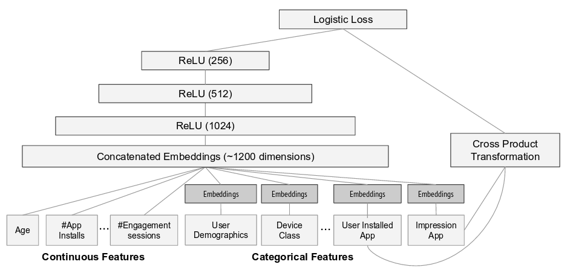

```python
Image('images/WND structure.png')
```

위 그림은 [Wide & Deep Learning for Recommender Systems[3]](https://arxiv.org/abs/1606.07792)논문에서 실제 Google Play Apps 에 적용한 모형 Graphs 입니다.  
이번 분석에서 다루는 데이터의 형태가 Google Apps 데이터와 다르므로 Input 형태가 다소 다를 수 있지만 큰 틀에서 아주 비슷하다고 할 수 있습니다.

```python
# parameters
# keep_prob = 0.5
learning_rate = 1e-4
training_epochs = 10
batch_size = 256

wide_size = len(Wide_data.columns)
deep_size = len(Deep_data.columns)
deep_embed_size = 3 # 임베딩할 컬럼 개수

output_size = len(train_label.columns)

He = tf.contrib.layers.variance_scaling_initializer()

# input place holders
tf.reset_default_graph()
Wide = tf.placeholder(tf.float32, [None, wide_size])
Deep_un_embed = tf.placeholder(tf.float32, [None, deep_size - deep_embed_size])
Deep_embed = tf.placeholder(tf.int32, [None, deep_embed_size])

Y = tf.placeholder(tf.float32, [None, output_size])
train_mode = tf.placeholder(tf.bool, name='train_mode')
```

`embedding_lookup` 함수를 이용해서 categorical 변수를 Embedding 합니다.

```python
no_class_max = 42
embedding_size = 5

deep_embed_var = tf.Variable(tf.random_uniform([no_class_max, embedding_size], -1.0, 1.0))
deep_embed = tf.nn.embedding_lookup(deep_embed_var, Deep_embed)
deep_embed_re = tf.reshape(deep_embed, [-1, embedding_size * deep_embed_size])
```

```python
Deep = tf.concat([Deep_un_embed, deep_embed_re], axis=1)
```

```python
Deep
```

```
<tf.Tensor 'concat:0' shape=(?, 332) dtype=float32>
```

원래 Deep learning에 들어갈 input의 column 수는 320 개 였는데, 그 중 3개의 categorical 변수를 각각 5차원으로 Embedding하면 320 - 3 + 15 = 332 이 됩니다.

### Wide

```python
A = tf.get_variable("A", shape=[wide_size, output_size])
b = tf.Variable(tf.random_normal([output_size]))

wide = tf.add(tf.matmul(Wide, A), b)
```

### Deep

```python
W1 = tf.get_variable("W1", shape=[332, 512], initializer=He)
b1 = tf.Variable(tf.random_normal([512]))
L1 = tf.nn.relu(tf.matmul(Deep, W1) + b1)

W2 = tf.get_variable("W2", shape=[512, 256], initializer=He)
b2 = tf.Variable(tf.random_normal([256]))
L2 = tf.nn.relu(tf.matmul(L1, W2) + b2)

W3 = tf.get_variable("W3", shape=[256, 128], initializer=He)
b3 = tf.Variable(tf.random_normal([128]))
L3 = tf.nn.relu(tf.matmul(L2, W3) + b3)

W4 = tf.get_variable("W4", shape=[128, output_size], initializer=He)
b4 = tf.Variable(tf.random_normal([output_size]))

deep = tf.add(tf.matmul(L3, W4), b4)
```

```python
hypothesis = wide + deep
```

```python
global_step = tf.Variable(initial_value=0, name='global_step', trainable=False)
```

```python
cost = tf.reduce_mean(tf.nn.sigmoid_cross_entropy_with_logits(logits=hypothesis, labels=Y))
optimizer = tf.train.AdamOptimizer(learning_rate=learning_rate).minimize(cost, global_step=global_step)
```

### Session

```python
config = tf.ConfigProto()
config.gpu_options.allow_growth=True
sess = tf.Session(config=config)
sess.run(tf.global_variables_initializer())
```

### saver

```python
import os
save_dir = 'W&D-checkpoints/'
if not os.path.exists(save_dir):
    os.makedirs(save_dir)
save_path = os.path.join(save_dir, 'Recommendation_DM_W&D')
saver = tf.train.Saver()
```

```python
try:
    print("가장 최근 체크포인트를 로드합니다.")
    last_chk_path = tf.train.latest_checkpoint(checkpoint_dir=save_dir)
    saver.restore(sess, save_path=last_chk_path)
    print("Restored checkpoint from:", last_chk_path)

except:
    print("체크포인트가 없습니다. 변수를 초기화 합니다.")
    sess.run(tf.global_variables_initializer())
```

```
가장 최근 체크포인트를 로드합니다.
INFO:tensorflow:Restoring parameters from W&D-checkpoints/Recommendation_DM_W&D-3710
Restored checkpoint from: W&D-checkpoints/Recommendation_DM_W&D-3710
```

10 번 학습합니다.

```python
def Model_train(training_epochs = 10):
    for epoch in range(training_epochs):
        avg_cost = 0
        total_batch = int(len(Deep_data) / batch_size)

        for i in range(0, len(Deep_data), batch_size):
            batch_wide = Wide_data[i:i+batch_size]
            batch_deep = Deep_data[i:i+batch_size][Deep_col[:-3]]
            batch_deep_embed = Deep_data[i:i+batch_size][Deep_col[-3:]]

            batch_label = train_label[i:i+batch_size]

            feed_dict_train = {Wide: batch_wide,
                               Deep_un_embed: batch_deep,
                               Deep_embed: batch_deep_embed,
                               Y: batch_label}
            i_global, opt, c = sess.run([global_step, optimizer, cost],
                                        feed_dict=feed_dict_train)

            avg_cost += c/total_batch

        if (epoch % 1 == 0) or (epoch == training_epochs - 1):
            time = datetime.now().strftime('%Y-%m-%d %H:%M:%S')
            print("[epoch: {:>4}][Cost: {:>.5f}][{}]".format(epoch, avg_cost, time))

        if (epoch % 10 == 0) or (epoch == training_epochs - 1):
            saver.save(sess, save_path=save_path, global_step=global_step)
            print("Saved checkpoint.")

    print('Learning Finished!')
```

```python
sess.run(tf.global_variables_initializer())
Model_train()
```

```
[epoch:    0][Cost: 0.20945][2017-08-23 18:22:33]
Saved checkpoint.
[epoch:    1][Cost: 0.02029][2017-08-23 18:22:41]
[epoch:    2][Cost: 0.01811][2017-08-23 18:22:50]
[epoch:    3][Cost: 0.01708][2017-08-23 18:22:58]
[epoch:    4][Cost: 0.01637][2017-08-23 18:23:06]
[epoch:    5][Cost: 0.01584][2017-08-23 18:23:14]
[epoch:    6][Cost: 0.01543][2017-08-23 18:23:23]
[epoch:    7][Cost: 0.01510][2017-08-23 18:23:31]
[epoch:    8][Cost: 0.01482][2017-08-23 18:23:39]
[epoch:    9][Cost: 0.01460][2017-08-23 18:23:47]
Saved checkpoint.
Learning Finished!
```

# 4. Recommendation

단순한 Accuracy를 확인하면 다음과 같습니다.

```python
Wide_data_test.shape
```

```
(13915, 878)
```

```python
Deep_data_test.shape
```

```
(13915, 320)
```

```python
YY = tf.equal(Y , 1)
XX = tf.greater(tf.sigmoid(hypothesis), 0.5)
correct = tf.equal(XX, YY)
# score = sess.run(correct, feed_dict={Wide: Wide_data_test, Deep: deep_data_test, Y: test_label_real})
accuracy = tf.reduce_mean(tf.cast(correct, 'float'))

feed_dict_test = {Wide: Wide_data_test,
                  Deep_un_embed: Deep_data_test[Deep_col[:-3]],
                  Deep_embed: Deep_data_test[Deep_col[-3:]],
                  Y: test_label_eval}

print("Accuracy: {:>.5f}".format(sess.run(accuracy, feed_dict=feed_dict_test)))
```

```
Accuracy: 0.99597
```

정확도가 99.597 % 정도가 나옵니다. scroe 값이 0.5 이상인 것만 추천을 해주는 방식인데  
실제 구매 개수는 min, avg, max=[1, 3.6, 50] 의 분포를 갖고  
추천 개수는 min, avg, max=[1, 3.5, 33] 값이 나왔습니다.  
매번 10개정도 틀린값이 나온다고 해도 868 / 878 = 0.988 가 나오기 때문에 이는 평가지표로 사용하기에 무리가 있습니다.

추천시스템은 일반적인 Accuracy를 이용하지 않습니다. 878개나 되는 Label을 맞출 리 없죠.  
보통은 Top 3 내지 Top 20을 추천을 하게 됩니다.  
그중 실제로 고객이 구매한 내역과 비교하여 Hit rate: (맞춘 개수 / 추천한 개수) 를 보게 됩니다.  
Hit rate 는 통계학에서 Precision (정밀도) 라는 용어로 사용되고 있습니다.

#### Precision = tp / (tp + fp)

| "" | Recommended | Not Recommended | Total |
| --- | --- | --- | --- |
| bought | tp | fn | "" |
| not bought | fp | tn | "" |
| Total | Top10 | 868 | 878 |

14674번 고객과 6887번 고객을 예를 들면 위 모델로 추천을 해준 아이템 10개는 다음과 같으며  
실제 고객이 구매한 아이템은 그 밑에 나타냈습니다.

### ID: 14674

```
list(test_label.iloc[0])
list(score.iloc[0].nlargest(10).index)
```

- 추천 상품

| 상품 명 | 상품 명 | 상품 명 |
| --- | --- | --- |
| 'C060504/기타냉장조리' | 'C060406/베이커리일반빵' | 'C060402/일반빵' |
| 'C060503/기타온장조리' | 'C060506/일반떡' | 'C060403/호빵찐빵' |
| 'C060401/식빵' | 'C060502/피자' | 'C060205/즉석어묵' |
| 'C060206/온장조리원부재료' |  |  |

- 실제 마지막 구매 상품

| 상품 명 | 상품 명 | 상품 명 |
| --- | --- | --- |
| 'C060206/온장조리원부재료' |  |  |

- 추천한 상품 중 실제 구매한 품목: (1/10)

| 상품 명 | 상품 명 | 상품 명 |
| --- | --- | --- |
| 'C060206/온장조리원부재료' |  |  |

> 14674 번 고객은 **'온장조리원부재료'**를 딱 2번 구매한 고객입니다. 이렇게 고객의 구매 데이터가 없어도 **`기타냉장조리`, `기타온장조리`** 등 큰 범주에서 비슷한 상품들을 추천해주는 모습입니다.

### ID: 6887

```
list(test_label.iloc[1234])
list(score.iloc[1234].nlargest(10).index)
```

- 추천 상품

| 상품 명 | 상품 명 | 상품 명 |
| --- | --- | --- |
| 'C060504/기타냉장조리' | 'C150302/쿠키' | 'C150306/파이' |
| 'C150405/일반스낵' | 'C060402/일반빵' | 'C150103/국물용기라면' |
| 'C150301/크래커' | 'C060406/베이커리일반빵' | 'C150601/판초콜릿' |
| 'C150101/국물봉지라면' |  |  |

- 실제 마지막 구매 상품

| 상품 명 | 상품 명 | 상품 명 |
| --- | --- | --- |
| 'C060403/호빵찐빵' | 'C150602/쉘초콜릿' | 'C150603/바초콜릿' |

- 추천한 상품 중 실제 구매한 품목: (0/10)

| 상품 명 | 상품 명 | 상품 명 |
| --- | --- | --- |

> 비록 정확도는 낮지만 추천 아이템을 살펴보면,  
> 전혀 쌩뚱맞은 추천이 아니라 실제 구매한 아이템과 어느정도 연관성이 있음을 알 수 있습니다. **쉘초콜릿, 바초콜릿** 을 구매한 고객에게 **판초콜릿** 을 추천한 모습이 인상적입니다.

```python
def get_acc(score_matrix, top_n, test_matix):
    avg_acc = 0
    for i in range(len(score_matrix)):
        top = score_matrix.iloc[i].nlargest(top_n).index
        tmp = 0
        for j in range(len(top)):
            if top[j] in test_matix["item"][i].split():
                tmp += 1

        acc = tmp / len(top)
        avg_acc += acc / len(score_matrix)

    return avg_acc
```

```python
def Model_eval(training_epochs = 10):
    for epoch in range(training_epochs):
        avg_cost = 0
        total_batch = int(len(Deep_data) / batch_size)

        for i in range(0, len(Deep_data), batch_size):
            batch_wide = Wide_data[i:i+batch_size]
            batch_deep = Deep_data[i:i+batch_size][Deep_col[:-3]]
            batch_deep_embed = Deep_data[i:i+batch_size][Deep_col[-3:]]

            batch_label = train_label[i:i+batch_size]

            feed_dict_train = {Wide: batch_wide,
                               Deep_un_embed: batch_deep,
                               Deep_embed: batch_deep_embed,
                               Y: batch_label}

            feed_dict_test = {Wide: Wide_data_test,
                              Deep_un_embed: Deep_data_test[Deep_col[:-3]],
                              Deep_embed: Deep_data_test[Deep_col[-3:]],
                              Y: test_label_eval}

            i_global, opt, c = sess.run([global_step, optimizer, cost], feed_dict=feed_dict_train)

            avg_cost += c/total_batch

        score = sess.run(tf.sigmoid(hypothesis), feed_dict=feed_dict_test)
        score_pd = pd.DataFrame(score, columns=train_label.columns)
        acc = get_acc(score_pd, 10, test_label)

        if (epoch % 1 == 0) or (epoch == training_epochs - 1):
            time = datetime.now().strftime('%Y-%m-%d %H:%M:%S')
            main = "[Epoch: {:>4}][Cost: {:>.5f}][Hit rate of Top 10: {:>.5f}]"
            print(main.format(epoch, avg_cost, acc))
#             print("[global_step: {:>4}][{}]".format(i_global, time))

        if (epoch % 10 == 0) or (epoch == training_epochs - 1):
            saver.save(sess, save_path=save_path, global_step=global_step)
            print("Saved checkpoint.")

    print('Learning Finished!')
```

몇번의 사전적인 실험에서 epoch가 10 근방에서 HroT10 이 가장 높았습니다. (최대 10000 번까지 실험해 보았다.)

```python
sess.run(tf.global_variables_initializer())
Model_eval(10)
```

```
[Epoch:    0][Cost: 0.20908][Hit rate of Top 10: 0.09963]
Saved checkpoint.
[Epoch:    1][Cost: 0.01991][Hit rate of Top 10: 0.12865]
[Epoch:    2][Cost: 0.01798][Hit rate of Top 10: 0.14559]
[Epoch:    3][Cost: 0.01698][Hit rate of Top 10: 0.15342]
[Epoch:    4][Cost: 0.01629][Hit rate of Top 10: 0.15815]
[Epoch:    5][Cost: 0.01578][Hit rate of Top 10: 0.16032]
[Epoch:    6][Cost: 0.01538][Hit rate of Top 10: 0.16133]
[Epoch:    7][Cost: 0.01506][Hit rate of Top 10: 0.16227]
[Epoch:    8][Cost: 0.01480][Hit rate of Top 10: 0.16269]
[Epoch:    9][Cost: 0.01458][Hit rate of Top 10: 0.16280]
Saved checkpoint.
Learning Finished!
```

```python
score = sess.run(tf.sigmoid(hypothesis), feed_dict=feed_dict_test)
score = pd.DataFrame(score, columns=train_label.columns)
```

```python
print("Hit rate of Top 3: {:>.5f}".format(get_acc(score, 3, test_label)))
print("Hit rate of Top 10: {:>.5f}".format(get_acc(score, 10, test_label)))
```

```
Hit rate of Top 3: 0.25986
Hit rate of Top 10: 0.16280
```

3개를 추천해준다면 그 중 25.986%,  
10개를 추천해준다면 그 중 16.280% 가량을 실제로 구매하는 것으로 나타났습니다.

# 5. Cold start 문제

Cold start 문제란 구매이력이 없는 User에게 추천을 해주는 문제를 말합니다.  
기존의 CF 에서는 Rating에 의존한 추천을 해주다 보니, 이런 구매이력이 없는 고객에게는 추천을 하지 못하는 문제가 있었습니다. 그러다 보니 보통 가장 인기가 많은 Item들을 추천을 해주는 경향이 있습니다.  
Neural Network를 이용한 모형에서도 이러한 문제가 존재합니다. 하지만 이 모형에는 고객의 특징을 설명하는 변수가 존재하기 때문에 **User Feaures**를 이용해서 추천을 해 주는 것이 가능합니다.

위 모형에서 구매 이력이 단 1개인 고객은 분석에서 제외했었습니다. Train set만 있고 Test set 이 없었기 때문입니다.

이번 단계에서 그 고객의 User Feature만 사용해 추천을 하고, 그 1번 뿐인 구매이력으로 정확도를 측정하도록 하겠습니다.

```python
pred_label = pd.read_csv("./Lpoint_C/data/pred_label.csv", encoding="cp949")
pred_label_eval = pd.read_csv("./Lpoint_C/data/pred_label_real.csv", encoding="cp949")
pred_user_feartures = pd.read_csv("./Lpoint_C/data/pred_categorical.csv", encoding="cp949")
```

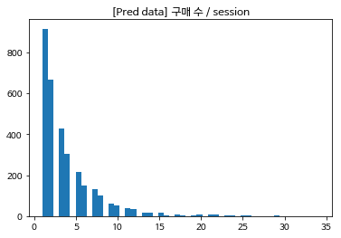

```python
Pred_session = pred_label_eval.apply(np.sum, axis=1)

plt.hist(Pred_session, 50)
plt.title(u'[Pred data] 구매 수 / session')
plt.show()
```

```python
pred_user_feartures_ = cp.deepcopy(pred_user_feartures)
pred_user_feartures_["성별"] = le.fit_transform(pred_user_feartures_["성별"])
pred_user_feartures_["연령대"] = le.fit_transform(pred_user_feartures_["연령대"])
pred_user_feartures_["A거주지역"] = le.fit_transform(pred_user_feartures_["A거주지역"])

pred_user_feartures_.head()
```

|  | 성별 | 연령대 | A거주지역 |
| --- | --- | --- | --- |
| 0 | 0 | 7 | 6 |
| 1 | 0 | 9 | 6 |
| 2 | 0 | 5 | 6 |
| 3 | 0 | 4 | 6 |
| 4 | 0 | 5 | 1 |

```python
print(Wide_data.shape)
print(Deep_data.shape)
```

```
(94785, 878)
(94785, 320)
```

구매이력이 없으므로, zero 벡터로 Input matrix를 채웁니다.

```python
Wide_data_pred = pd.DataFrame(np.zeros((3195, 878)))
Wide_data_pred.columns = Wide_data.columns
```

```python
Deep_data_pred_ = pd.DataFrame (np.zeros((3195, 317)))
Deep_data_pred = pd.concat([Deep_data_pred_, pred_user_feartures_], axis=1)
Deep_data_pred.columns = Deep_data.columns
```

```python
print(Wide_data_pred.shape)
print(Deep_data_pred.shape)
```

```
(3195, 878)
(3195, 320)
```

```python
feed_dict_pred = {Wide: Wide_data_pred,
                  Deep_un_embed: Deep_data_pred[Deep_col[:-3]],
                  Deep_embed: Deep_data_pred[Deep_col[-3:]]}
```

```python
score_pred = sess.run(tf.sigmoid(hypothesis), feed_dict=feed_dict_pred)
score_pred = pd.DataFrame(score, columns=train_label.columns)
```

```python
print("Hit rate of Top 3: {:>.5f}".format(get_acc(score_pred, 3, pred_label)))
print("Hit rate of Top 10: {:>.5f}".format(get_acc(score_pred, 10, pred_label)))
```

```
Hit rate of Top 3: 0.02900
Hit rate of Top 10: 0.02291
```

정확도는 형편없습니다...

한번도 구매하지 않은고객 3195명의 고객 중 랜덤하게 7명을 골라 어떻게 추천을 해주었는지 확인을 해보았습니다. (Top 5)

```python
reco = []
for i in [0, 5, 10, 50, 100, 500, 1000]:
    reco.append(list(score.iloc[i].nlargest(5).index))

reco_pd = pd.DataFrame(reco)
```

```python
random_user =  pred_user_feartures.loc[[0, 5, 10, 50,100, 500, 1000]]
```

```python
how_reco = pd.concat([random_user.reset_index(drop=True), reco_pd], axis=1)
how_reco
```

|  | 성별 | 연령대 | A거주지역 | 0 | 1 | 2 | 3 | 4 |
| --- | --- | --- | --- | --- | --- | --- | --- | --- |
| 0 | F | 50세~54세 | A24 | C150103/국물용기라면 | C050108/한우양지 | C070101/일반우유 | C070302/치즈 | C070402/냉장과일야채음료 |
| 1 | F | 40세~44세 | A16 | C050108/한우양지 | C150103/국물용기라면 | C070101/일반우유 | C070302/치즈 | C070402/냉장과일야채음료 |
| 2 | M | 40세~44세 | A20 | C050108/한우양지 | C150103/국물용기라면 | C070302/치즈 | C070101/일반우유 | C070402/냉장과일야채음료 |
| 3 | F | 35세~39세 | A100 | C150103/국물용기라면 | C050108/한우양지 | C070101/일반우유 | C070402/냉장과일야채음료 | C070302/치즈 |
| 4 | F | 50세~54세 | A100 | C050108/한우양지 | C150103/국물용기라면 | C070101/일반우유 | C070402/냉장과일야채음료 | C070302/치즈 |
| 5 | F | 40세~44세 | A270 | C150103/국물용기라면 | C050108/한우양지 | C070402/냉장과일야채음료 | C070101/일반우유 | C070302/치즈 |
| 6 | M | 45세~49세 | A13 | C050108/한우양지 | C150103/국물용기라면 | C070302/치즈 | C070101/일반우유 | C070402/냉장과일야채음료 |

성별, 연령대, 거주지역에 따라 그 순서가 약간 다르긴 하지만,  
전체적으로 국물용기라면, 한우양지, 일반우유, 치즈, 냉장과일야채음료 등을 추천을 해줍니다.

설명 변수로 사용되는 User Feature들이 다양할 수록 그 결과갑이 좋을것으로 예상되며  
Doc2Vec과 Wide&Deep 모형들의 변수들이 random 하게 update 되므로 위 결과갑도 그때 그때 다르게 나옵니다. 모형을 구축할 때 정확히 저장을 해야 할 것 같습니다.

# 6. 결론

다시 한번 말하지만, 추천시스템은 정확도로 판단을 하는 모형이 아닙니다. 2%의 예측력이 갖는 의미가 이해되지 않는다면, 당신이 11번가나 쿠팡에 들어갔을 때 홈페이지 첫 Index화면에 추천받았던 상품 중에 실제로 구매를 얼만큼 했나 생각해 보시면 2%가 갖는 의미를 파악하실 수 있을 것입니다.  
(사실 대 분류 측면으로 정확도를 측정하면 정확도가 높게 나올 수 있을 것입니다.)

상춤 추천은 추천 이후에 또다른 처리작업이 필요할 것입니다. 예를들어 넷플릭스가 한 번 본 영화를 다시 추천해주지 않는다거나, 아마존이 미성년자에게 성인상품을 추천해주지 않는다는 특별한 처리과정이 필요할 수 있습니다.

위 분석에서는 한달 전 고가의 가전제품(냉장고, 세탁기)을 구매한 고객에게 재 구매를 요구하지 않는다거나, 생활필수품 중 재 구매율이 높은(종량제 봉투)를 추천해 주지 않는 작업이 필요할 것입니다.

위 추천방식에서 사용한 방법 말고 다른 방법들도 다수 존재합니다. 예를 들어 온라인 쇼핑몰 검색창에 Query:"사과"를 검색했을 때 사과와 같이 다른 상품들을 추천해줄 수 도 있습니다.

# Reference

### [[1] Recommender System with Distributed Representation](https://www.slideshare.net/rakutentech/recommender-system-with-distributed-representation)

### [[2] Distributed Representations of Sentences and Documents](https://arxiv.org/abs/1405.4053)

### [[3] Wide & Deep Learning for Recommender Systems](https://arxiv.org/abs/1606.07792)

### [[4] TensorFlow Wide & Deep Learning Tutorial](https://www.tensorflow.org/tutorials/wide_and_deep)

### [[5] Korean NLP in Python](http://konlpy.org/en/v0.4.4/)